# Healthcare Application: Forecasting Home Deliveries

[figure not shown]

# Healthcare Application: Forecasting Home Deliveries

Kyle Admire, Travis Frocione, Tashuna Jackson, Xenia Liu, Le Nhan, Megan Williams

2023-01-08

## Introduction

**One application of machine learning in healthcare is using time series to predict outcomes of longitudinal data. Longitudinal data is described by data that is recorded from the same source over many times. Examples of this are global temperature data and stock market data. However, longitudinal data is also present in healthcare.**

**Time series analysis fits a model to this longitudinal data, which allows us to predict future outcomes. Our model will be the ARIMA model, which uses previous data points and model predictions to predict future data.**

**In our example, we found a maternal health dataset from India with the variable, “Number of Home Deliveries Attended By A Skilled Birth Attendant,” which covers data from 2015 to 2019. With this data, we can predict how many home deliveries will be attended by a skilled birth attendant well into the year 2020.**

**Machine learning can help achieve this task by allowing us to split the data into different sets: training and testing. However, unlike k-fold cross validation, the test set is not randomly chosen. Instead, the test set only consists of the most recent data points. All of the oldest data points are put into the training set, which is then used to predict the testing set.**

## Preparing the Time Series

**First, we review what the original data, which is shown below. This data seems to have a downward trend that appears to be seasonal due to the spikes throughout the years.**

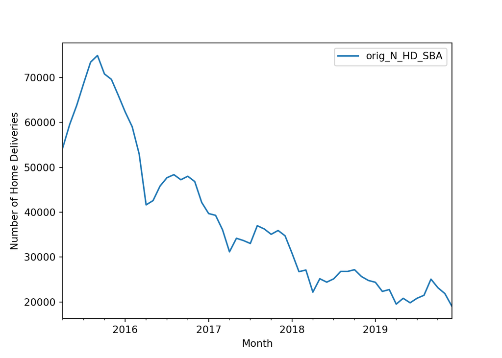

**Before fitting our model, we should use transformations to make the model stationary and remove those trends. This can be accomplished with a simple transformation called differencing, which replaces the data by a difference of adjacent data points. This transformation is demonstrated in the image below.**

$$D_t = Y_t - Y_{t-1}$$

**Now, we can visualize the data if we use the transformed data,** $D_t$, **instead of the original data,** $Y_t$.

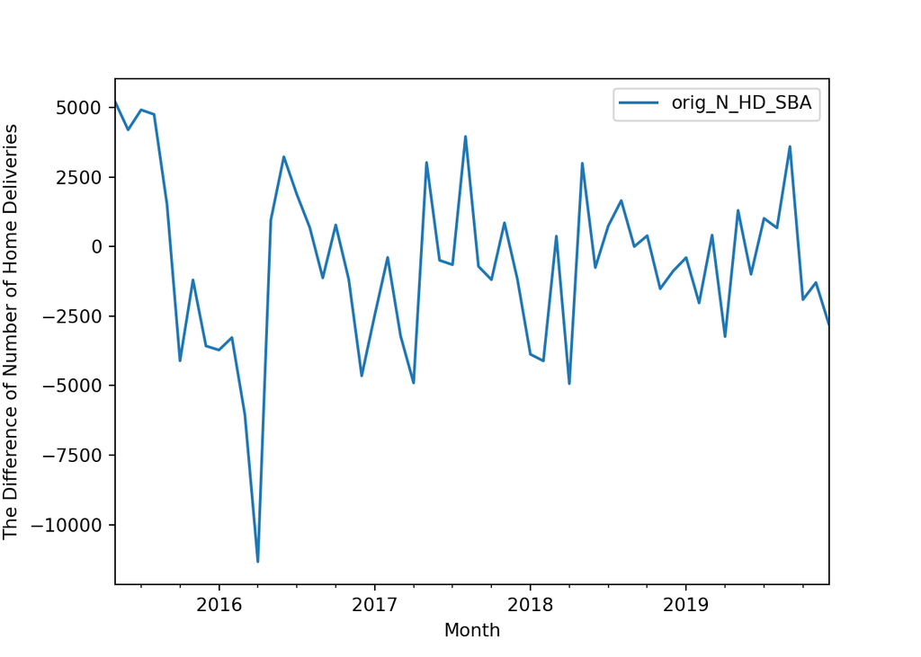

**Since this time series looks stationary and has no trends, we can fit the model.**

## Seasonal ARIMA models

**To fit the model, we need to compare the dependencies of each data point with every other data point. We can do this by using the ACF and PACF plots. Each of these plots shows the correlation between different lags of the data. Lag 1 shows how correlated adjacent data points are to each other. Lag 2, which is a fixed amount of passing time, shows the correlation between the data points that are two time periods apart.**

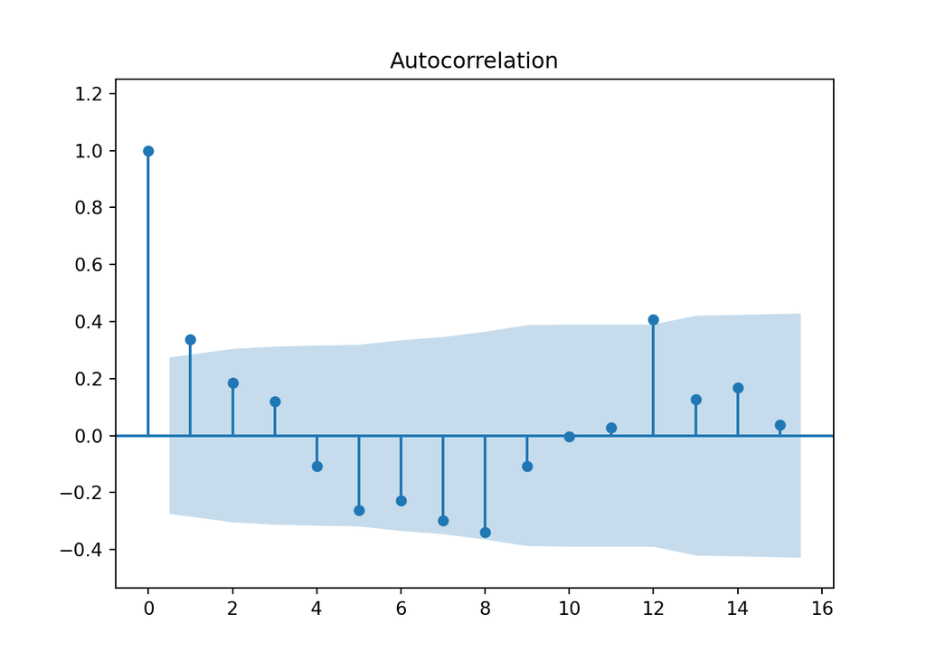

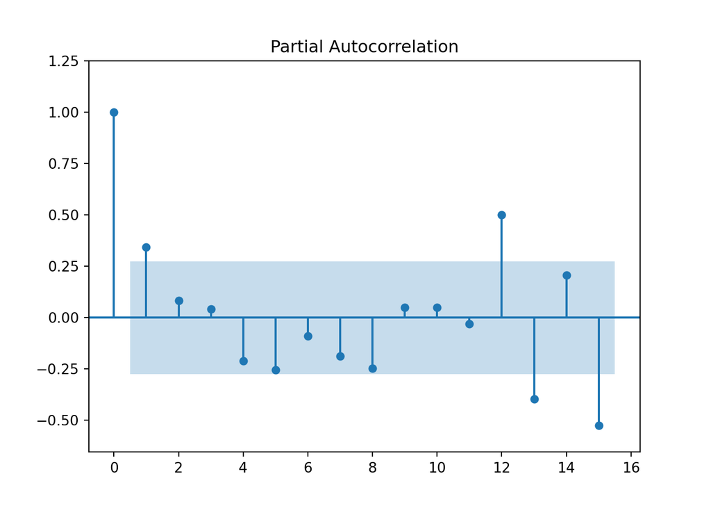

**Since both the ACF and the PACF show some correlations, both are included in the short lags and the lags around 12 time periods. We decided to fit a seasonal arima model using the forward selection process. The best fitted model was:**

$$D_t = \beta_0 + \beta_1 e_{t-1} + \beta_2 D_{t-12} + \beta_3 D_{t-24} +
e_t$$

**Where** $e_t$ **is the random error of the model.**

## Result

**The results of our seasonal arima model and confidence interval are shown below.**

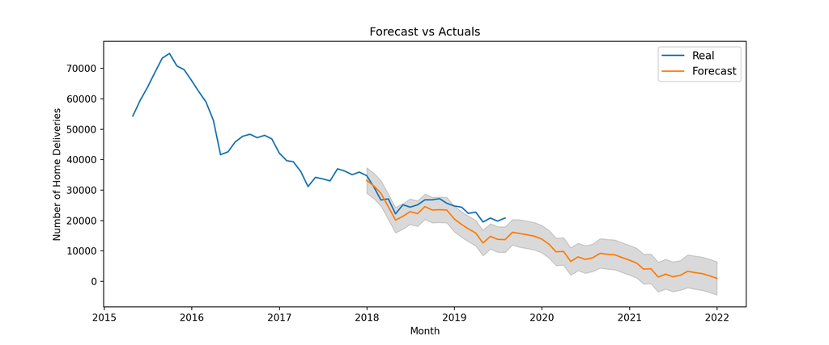

**Although the model is not perfect, it shows the general trend of the number of skilled birth attendants doing home deliveries in the future. It also includes the seasonal trend, which you can see by the small hills in the forecast. This can be very useful for people working in healthcare since preparations can be made in advance by checking the previous year’s data.**